# Maths Project

Dhananjay Kumar

5/18/2017

```r
# Import Libraries

library(MASS)
library(forecast)
```

##### Load data set

```r
train<-read.csv("train.csv")
```

##### 1.Probability

Pick one of the quantitative independent variables from the training data set (train.csv) , and define that variable as X. Pick SalePrice as the dependent variable, and define it as Y for the next analysis.

```r
dim(train)
```

```
## [1] 1460   81
```

In our analysis we will take LotArea as the independent variable X.

Calculate as a minimum the below probabilities a through c. Assume the small letter “x” is estimated as the 4th quartile of the X variable, and the small letter “y” is estimated as the 2d quartile of the Y variable. Interpret the meaning of all probabilities

```r
x <- quantile(train$LotArea)["75%"]
y <- quantile(train$SalePrice)["50%"]
```

###### a.P(X>x | Y>y)

This represents the probability that value of X is above the 3rd Quartile given that Y is above the 2nd Quartile. In other words this represents the probability that the LotArea is above the 3rd Quartile given that the Sale Price is above the 2nd Quartile.

```r
total<-nrow(train)
xg_yg<-nrow(subset(train,LotArea>x & SalePrice>y))
yg<-nrow(subset(train,SalePrice>y))
p1<-xg_yg/total
p2<-yg/total
a<-p1/p2
a
```

```
## [1] 0.3791209
```

###### b. P(X>x, Y>y)

This represents the probability that value of X is above the 3rd Quartile and Y is above 2nd Quartile. In other words this represents the probability that the LotArea is above the 3rd Quartile and the Sale Price is above the 2nd Quartile.

```r
xg<-nrow(subset(train,LotArea>x))
yg<-nrow(subset(train,SalePrice>y))
p3 <-xg/total
p4<-yg/total
b<-p3*p4
b
```

```
## [1] 0.1246575
```

```r
xl<-nrow(subset(train,LotArea<x))
yl<-nrow(subset(train,SalePrice<y))
p3 <-xl/total
p4<-yl/total
c<-p3*p4
c
```

```
## [1] 0.3739726
```

Does splitting the training data in this fashion make them independent? In other words, does P(X|Y)=P(X)P(Y))? Check mathematically, and then evaluate by running a Chi Square test for association. You might have to research this.

```r
# Check P(A|B) = P(A).P(B)
A<-xg
B<-yg
p6=p1/p4
p7=p3*p4
check<-(p6==p7)
check
```

```
## [1] FALSE
```

###### Chi-sq test for Independence

H0: SalesPrice and LotArea are independent Ha: SalesPrice and LotArea are not independent

```r
tbl = table(train$LotArea, train$SalePrice)
chisq.test(tbl)
```

```
##
##  Pearson's Chi-squared test
##
## data:  tbl
## X-squared = 735090, df = 709660, p-value < 2.2e-16
```

p-value < 2.2e-16, since p value <0.05 we reject the null hypothesis.

##### 2.Descriptive and Inferential Statistics

Provide univariate descriptive statistics and appropriate plots for both variables. Provide a scatterplot of X and Y. Transform both variables simultaneously using Box-Cox transformations. You might have to research this. Using the transformed variables, run a correlation analysis and interpret. Test the hypothesis that the correlation between these variables is 0 and provide a 99% confidence interval. Discuss the meaning of your analysis

###### Summary

```r
summary(train$SalePrice)
```

```
##    Min. 1st Qu.  Median    Mean 3rd Qu.    Max.
##   34900  130000  163000  180900  214000  755000
```

```r
summary(train$LotArea)
```

```
##    Min. 1st Qu.  Median    Mean 3rd Qu.    Max.
##    1300    7554    9478   10520   11600  215200
```

###### Scatter Plot

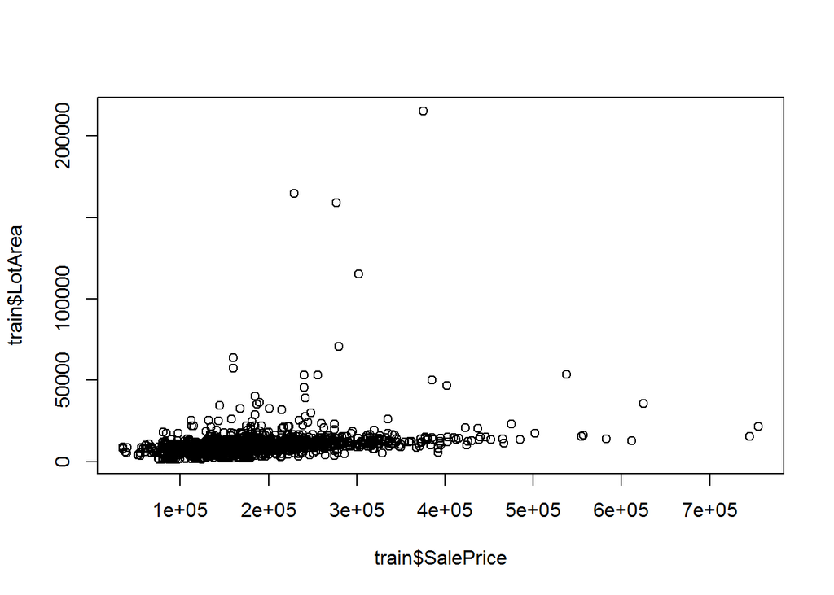

```r
plot(train$SalePrice,train$LotArea)
```

###### Histogram

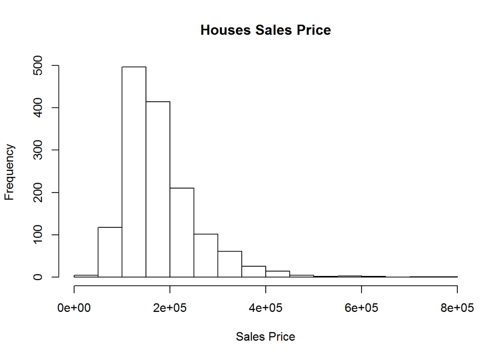

```r
hist(train$SalePrice,xlab= "Sales Price", main = "Houses Sales Price")
```

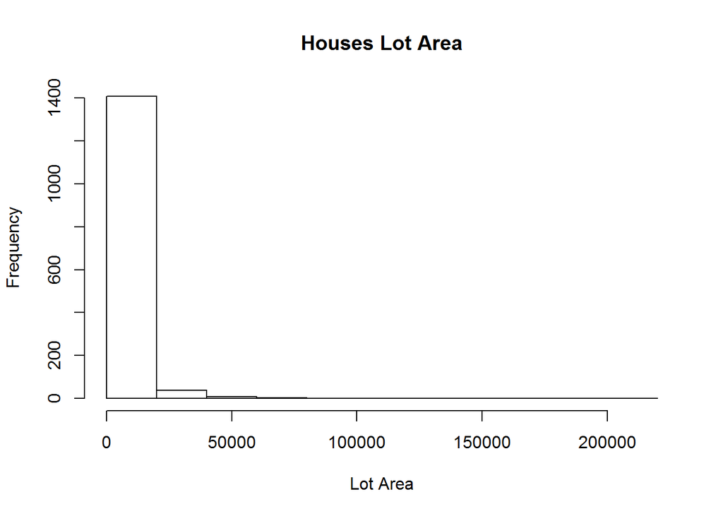

```r
hist(train$LotArea,xlab= "Lot Area", main = "Houses Lot Area")
```

###### Box Cox transforamtion on Sales Price and LotArea

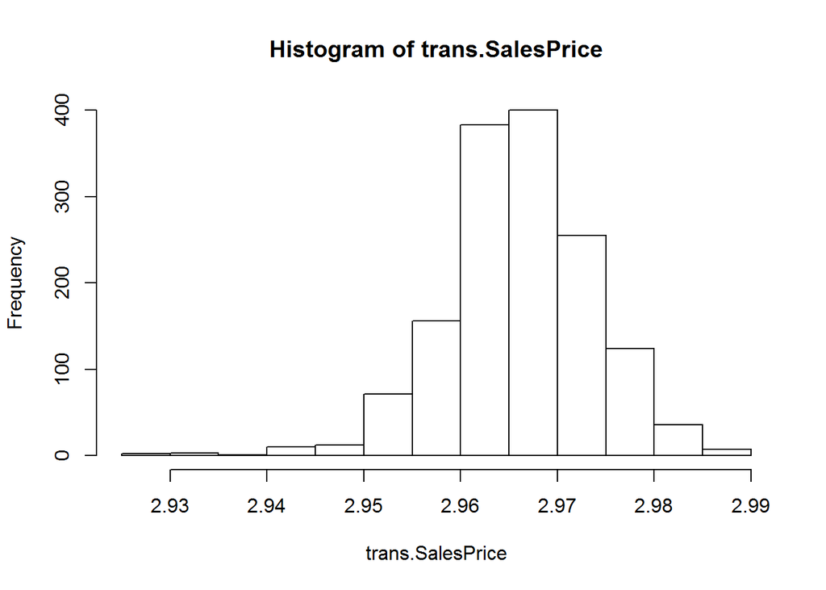

```r
lambda1 <-BoxCox.lambda(train$SalePrice)
trans.SalesPrice<-BoxCox(train$SalePrice,lambda1)
hist(trans.SalesPrice)
```

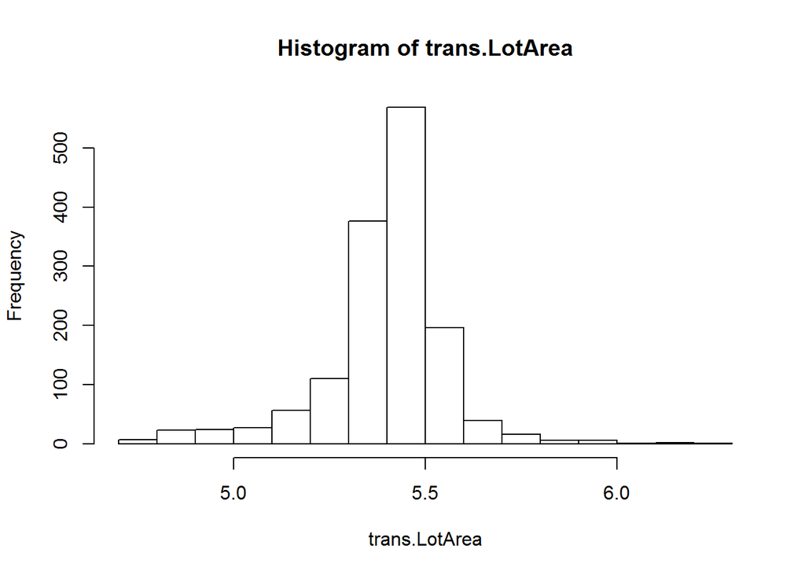

```r
lambda2 <-BoxCox.lambda(train$LotArea)
trans.LotArea<-BoxCox(train$LotArea,lambda2)
hist(trans.LotArea)
```

###### Correlation Anaylsis

Using the transformed variables, run a correlation analysis and interpret. Test the hypothesis that the correlation between these variables is 0 and provide a 99% confidence interval. Discuss the meaning of your analysis.

```r
# Correlation matrix
tab<- cbind(trans.SalesPrice,trans.LotArea)
mat<-cor(tab)
mat
```

```
##                  trans.SalesPrice trans.LotArea
## trans.SalesPrice        1.0000000     0.3893308
## trans.LotArea           0.3893308     1.0000000
```

###### Test the hypothesis

Cor-relation matrix shows there is a positive cor-relation between sales price and Lot area.

```r
cor.test(trans.SalesPrice,trans.LotArea, method = "pearson" , conf.level = 0.99)
```

```
##
##  Pearson's product-moment correlation
##
## data:  trans.SalesPrice and trans.LotArea
## t = 16.14, df = 1458, p-value < 2.2e-16
## alternative hypothesis: true correlation is not equal to 0
## 99 percent confidence interval:
##  0.3306244 0.4450358
## sample estimates:
##       cor
## 0.3893308
```

##### 3.Linear Algebra and Correlation

Invert your correlation matrix. (This is known as the precision matrix and contains variance inflation factors on the diagonal.) Multiply the correlation matrix by the precision matrix, and then multiply the precision matrix by the correlation matrix.

```r
# Invert correlation matrix (precision matrix)
inv<-solve(mat)
inv
```

```
##                  trans.SalesPrice trans.LotArea
## trans.SalesPrice        1.1786593    -0.4588883
## trans.LotArea          -0.4588883     1.1786593
```

```r
# Multiply the correlation matrix by the precision matrix
matrix1 <-mat  %*% inv
matrix1
```

```
##                  trans.SalesPrice trans.LotArea
## trans.SalesPrice     1.000000e+00             0
## trans.LotArea        5.551115e-17             1
```

```r
# Then multiply the precision matrix by the correlation matrix
matrix2<- inv %*% mat
matrix2
```

```
##                  trans.SalesPrice trans.LotArea
## trans.SalesPrice     1.000000e+00             0
## trans.LotArea        5.551115e-17             1
```

##### 4.Calculus-Based Probability & Statistics

For your non-transformed independent variable, location shift it so that the minimum value is above zero.

```r
# shift Independent variable (LotArea) such that min value is > 0
min_Lot <- min(train$LotArea,na.rm = TRUE)
min_Lot
```

```
## [1] 1300
```

The minimum value is already greater than 0 so we need not do any shift.

###### Density function

Load the MASS package and run fitdistr to fit a density function of your choice. Find the optimal value of the parameters for this distribution.

```r
df <- fitdistr(train$LotArea, 'exponential')
estimate <- df$estimate
```

Take 1000 samples from this distribution (e.g., rexp(1000, l) for an exponential). Plot a histogram and compare it with a histogram of your non-transformed original variable

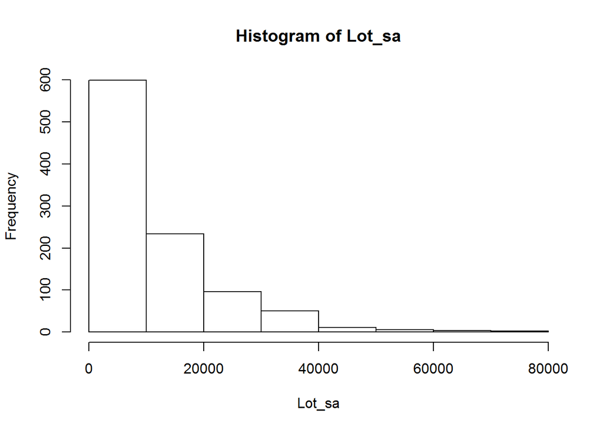

```r
Lot_sa<- rexp(1000, estimate)
hist(Lot_sa)
```

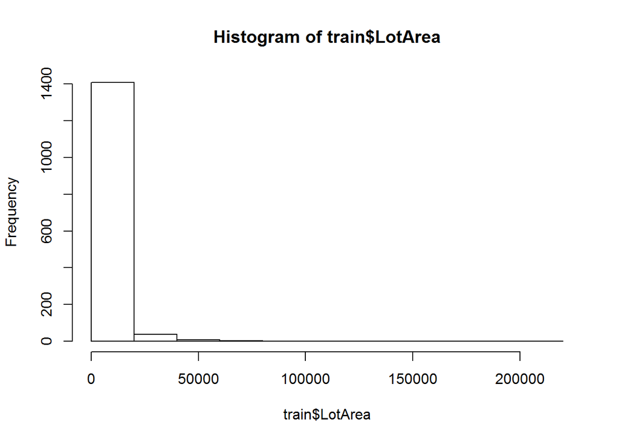

```r
# Histogram of non-trnasformed LotArea
hist(train$LotArea)
```

comparing the histograms we see the data is still positively skewed as in the original dataset, but with the estimations, it is more spread out.

##### 5.Modeling

Build some type of regression model and submit your model to the competition board.

```r
summary(train)
```

```
##        Id           MSSubClass       MSZoning     LotFrontage
##  Min.   :   1.0   Min.   : 20.0   C (all):  10   Min.   : 21.00
##  1st Qu.: 365.8   1st Qu.: 20.0   FV     :  65   1st Qu.: 59.00
##  Median : 730.5   Median : 50.0   RH     :  16   Median : 69.00
##  Mean   : 730.5   Mean   : 56.9   RL     :1151   Mean   : 70.05
##  3rd Qu.:1095.2   3rd Qu.: 70.0   RM     : 218   3rd Qu.: 80.00
##  Max.   :1460.0   Max.   :190.0                  Max.   :313.00
##                                                  NA's   :259
##     LotArea        Street      Alley      LotShape  LandContour
##  Min.   :  1300   Grvl:   6   Grvl:  50   IR1:484   Bnk:  63
##  1st Qu.:  7554   Pave:1454   Pave:  41   IR2: 41   HLS:  50
##  Median :  9478               NA's:1369   IR3: 10   Low:  36
##  Mean   : 10517                           Reg:925   Lvl:1311
##  3rd Qu.: 11602
##  Max.   :215245
##
##   Utilities      LotConfig    LandSlope   Neighborhood   Condition1
##  AllPub:1459   Corner : 263   Gtl:1382   NAmes  :225   Norm   :1260
##  NoSeWa:   1   CulDSac:  94   Mod:  65   CollgCr:150   Feedr  :  81
##                FR2    :  47   Sev:  13   OldTown:113   Artery :  48
##                FR3    :   4              Edwards:100   RRAn   :  26
##                Inside :1052              Somerst: 86   PosN   :  19
##                                          Gilbert: 79   RRAe   :  11
##                                          (Other):707   (Other):  15
##    Condition2     BldgType      HouseStyle   OverallQual
##  Norm   :1445   1Fam  :1220   1Story :726   Min.   : 1.000
##  Feedr  :   6   2fmCon:  31   2Story :445   1st Qu.: 5.000
##  Artery :   2   Duplex:  52   1.5Fin :154   Median : 6.000
##  PosN   :   2   Twnhs :  43   SLvl   : 65   Mean   : 6.099
##  RRNn   :   2   TwnhsE: 114   SFoyer : 37   3rd Qu.: 7.000
##  PosA   :   1                 1.5Unf : 14   Max.   :10.000
##  (Other):   2                 (Other): 19
##   OverallCond      YearBuilt     YearRemodAdd    RoofStyle
##  Min.   :1.000   Min.   :1872   Min.   :1950   Flat   :  13
##  1st Qu.:5.000   1st Qu.:1954   1st Qu.:1967   Gable  :1141
##  Median :5.000   Median :1973   Median :1994   Gambrel:  11
##  Mean   :5.575   Mean   :1971   Mean   :1985   Hip    : 286
##  3rd Qu.:6.000   3rd Qu.:2000   3rd Qu.:2004   Mansard:   7
##  Max.   :9.000   Max.   :2010   Max.   :2010   Shed   :   2
##
```

[output cut: 89 more lines]

```
##  GdPrv:  59   Gar2:   2   Min.   :    0.00   Min.   : 1.000
##  GdWo :  54   Othr:   2   1st Qu.:    0.00   1st Qu.: 5.000
##  MnPrv: 157   Shed:  49   Median :    0.00   Median : 6.000
##  MnWw :  11   TenC:   1   Mean   :   43.49   Mean   : 6.322
##  NA's :1179   NA's:1406   3rd Qu.:    0.00   3rd Qu.: 8.000
##                           Max.   :15500.00   Max.   :12.000
##
##      YrSold        SaleType    SaleCondition    SalePrice
##  Min.   :2006   WD     :1267   Abnorml: 101   Min.   : 34900
##  1st Qu.:2007   New    : 122   AdjLand:   4   1st Qu.:129975
##  Median :2008   COD    :  43   Alloca :  12   Median :163000
##  Mean   :2008   ConLD  :   9   Family :  20   Mean   :180921
##  3rd Qu.:2009   ConLI  :   5   Normal :1198   3rd Qu.:214000
##  Max.   :2010   ConLw  :   5   Partial: 125   Max.   :755000
##                 (Other):   9
```

```r
# removing featues having large number of NA's

drops <- c("Street","Alley","Utilities","LandSlope","BsmtFinSF2","Heating",
           "LowQualFinSF","BsmtFullBath","BsmtHalfBath","GarageYrBlt","EnclosedPorch",
           "3SsnPorch","ScreenPorch","PoolArea","PoolQC","Fence","MiscFeature",
           "MiscVal","YrSold","SaleType","SaleCondition","GarageQual","GarageCond",
           "LotFrontage","GarageType","GarageFinish","FireplaceQu","YearRemodAdd")
new_train<-train[ , !(names(train) %in% drops)]

new_train<-na.omit(new_train)
dim(new_train)
```

```
## [1] 1412   54
```

```r
str(new_train)
```

```
## 'data.frame':    1412 obs. of  54 variables:
##  $ Id          : int  1 2 3 4 5 6 7 8 9 10 ...
##  $ MSSubClass  : int  60 20 60 70 60 50 20 60 50 190 ...
##  $ MSZoning    : Factor w/ 5 levels "C (all)","FV",..: 4 4 4 4 4 4 4 4 5 4 ...
##  $ LotArea     : int  8450 9600 11250 9550 14260 14115 10084 10382 6120 7420 ...
##  $ LotShape    : Factor w/ 4 levels "IR1","IR2","IR3",..: 4 4 1 1 1 1 4 1 4 4 ...
##  $ LandContour : Factor w/ 4 levels "Bnk","HLS","Low",..: 4 4 4 4 4 4 4 4 4 4 ...
##  $ LotConfig   : Factor w/ 5 levels "Corner","CulDSac",..: 5 3 5 1 3 5 5 1 5 1 ...
##  $ Neighborhood: Factor w/ 25 levels "Blmngtn","Blueste",..: 6 25 6 7 14 12 21 17 18 4 ...
##  $ Condition1  : Factor w/ 9 levels "Artery","Feedr",..: 3 2 3 3 3 3 3 5 1 1 ...
##  $ Condition2  : Factor w/ 8 levels "Artery","Feedr",..: 3 3 3 3 3 3 3 3 3 1 ...
##  $ BldgType    : Factor w/ 5 levels "1Fam","2fmCon",..: 1 1 1 1 1 1 1 1 1 2 ...
##  $ HouseStyle  : Factor w/ 8 levels "1.5Fin","1.5Unf",..: 6 3 6 6 6 1 3 6 1 2 ...
##  $ OverallQual : int  7 6 7 7 8 5 8 7 7 5 ...
##  $ OverallCond : int  5 8 5 5 5 5 5 6 5 6 ...
```

[output cut: 42 more lines]

###### Fit the multilinear regression model

```r
attach(new_train)
```

```r
drops1 <- c("Street","Alley","Utilities","LandSlope","BsmtFinSF2","Heating",
           "LowQualFinSF","BsmtFullBath","BsmtHalfBath","GarageYrBlt","EnclosedPorch",
           "3SsnPorch","ScreenPorch","PoolArea","PoolQC","Fence","MiscFeature",
           "MiscVal","YrSold","SaleType","SaleCondition","GarageQual","GarageCond",
           "LotFrontage","GarageType","GarageFinish","FireplaceQu","YearRemodAdd",
           "Exterior1st","BsmtFinType1","RoofStyle","Exterior2nd",        "BsmtFinType2","HeatingQC","OpenPorchSF","Foundation","Electrical","WoodDeckSF", "X3SsnPorch","CentralAir","PavedDrive","MoSold","LotShape","GarageCars","HalfBath", "ExterCond","Id")
new_train<-train[ , !(names(train) %in% drops1)]
f11<-lm(SalePrice ~ .,data =new_train)
summary(f11)
```

```
##
## Call:
## lm(formula = SalePrice ~ ., data = new_train)
##
## Residuals:
##     Min      1Q  Median      3Q     Max
## -186873  -10425     376    9916  186873
##
## Coefficients:
##                       Estimate Std. Error t value Pr(>|t|)
## (Intercept)         -1.419e+06  1.302e+05 -10.904  < 2e-16 ***
## MSSubClass          -1.035e+02  8.325e+01  -1.243 0.213908
## MSZoningFV           3.609e+04  1.182e+04   3.053 0.002313 **
## MSZoningRH           2.342e+04  1.182e+04   1.982 0.047711 *
## MSZoningRL           2.762e+04  9.905e+03   2.788 0.005380 **
## MSZoningRM           2.567e+04  9.228e+03   2.782 0.005481 **
## LotArea              4.762e-01  8.235e-02   5.782 9.22e-09 ***
## LandContourHLS       1.182e+04  5.131e+03   2.304 0.021368 *
## LandContourLow      -5.152e+03  6.328e+03  -0.814 0.415703
## LandContourLvl       6.075e+03  3.583e+03   1.695 0.090270 .
## LotConfigCulDSac     8.004e+03  3.173e+03   2.522 0.011774 *
## LotConfigFR2        -6.811e+03  4.042e+03  -1.685 0.092244 .
## LotConfigFR3        -1.306e+04  1.298e+04  -1.006 0.314537
## LotConfigInside     -8.632e+02  1.759e+03  -0.491 0.623727
## NeighborhoodBlueste -4.460e+03  1.897e+04  -0.235 0.814201
## NeighborhoodBrDale  -3.593e+02  1.074e+04  -0.033 0.973310
## NeighborhoodBrkSide -3.881e+03  9.246e+03  -0.420 0.674716
## NeighborhoodClearCr -1.924e+04  9.051e+03  -2.126 0.033725 *
## NeighborhoodCollgCr -1.163e+04  7.207e+03  -1.614 0.106869
## NeighborhoodCrawfor  9.586e+03  8.392e+03   1.142 0.253520
## NeighborhoodEdwards -1.893e+04  7.952e+03  -2.381 0.017418 *
## NeighborhoodGilbert -1.307e+04  7.660e+03  -1.706 0.088287 .
## NeighborhoodIDOTRR  -8.972e+03  1.044e+04  -0.859 0.390515
## NeighborhoodMeadowV -7.556e+03  1.021e+04  -0.740 0.459222
## NeighborhoodMitchel -2.298e+04  8.106e+03  -2.835 0.004658 **
## NeighborhoodNAmes   -1.917e+04  7.677e+03  -2.497 0.012651 *
## NeighborhoodNoRidge  2.296e+04  8.339e+03   2.754 0.005971 **
## NeighborhoodNPkVill -4.407e+02  1.068e+04  -0.041 0.967083
## NeighborhoodNridgHt  1.433e+04  7.440e+03   1.925 0.054387 .
## NeighborhoodNWAmes  -2.419e+04  7.809e+03  -3.098 0.001990 **
```

[output cut: 73 more lines]

```
## FunctionalMaj2      -7.375e+03  1.351e+04  -0.546 0.585203
## FunctionalMin1       1.303e+03  8.734e+03   0.149 0.881411
## FunctionalMin2       4.301e+03  8.642e+03   0.498 0.618837
## FunctionalMod       -7.091e+02  1.060e+04  -0.067 0.946669
## FunctionalSev       -5.400e+04  2.764e+04  -1.954 0.050937 .
## FunctionalTyp        1.528e+04  7.494e+03   2.038 0.041709 *
## Fireplaces           3.121e+03  1.316e+03   2.371 0.017861 *
## GarageArea           2.145e+01  4.364e+00   4.914 1.01e-06 ***
## ---
## Signif. codes:  0 '***' 0.001 '**' 0.01 '*' 0.05 '.' 0.1 ' ' 1
##
## Residual standard error: 23950 on 1303 degrees of freedom
##   (46 observations deleted due to missingness)
## Multiple R-squared:  0.9158, Adjusted R-squared:  0.9087
## F-statistic: 128.8 on 110 and 1303 DF,  p-value: < 2.2e-16
```

##### Analysis of Variance Table

```r
anova(f11)
```

```
## Analysis of Variance Table
##
## Response: SalePrice
##                Df     Sum Sq    Mean Sq   F value    Pr(>F)
## MSSubClass      1 6.1248e+10 6.1248e+10  106.7616 < 2.2e-16 ***
## MSZoning        4 9.4363e+11 2.3591e+11  411.2084 < 2.2e-16 ***
## LotArea         1 4.2262e+11 4.2262e+11  736.6632 < 2.2e-16 ***
## LandContour     3 1.4999e+11 4.9995e+10   87.1462 < 2.2e-16 ***
## LotConfig       4 5.7037e+10 1.4259e+10   24.8553 < 2.2e-16 ***
## Neighborhood   24 3.5803e+12 1.4918e+11  260.0290 < 2.2e-16 ***
## Condition1      8 5.8743e+10 7.3428e+09   12.7992 < 2.2e-16 ***
## Condition2      7 4.4010e+10 6.2872e+09   10.9591 1.663e-13 ***
## BldgType        4 2.3412e+11 5.8530e+10  102.0227 < 2.2e-16 ***
## HouseStyle      7 1.1692e+11 1.6702e+10   29.1137 < 2.2e-16 ***
## OverallQual     1 1.0849e+12 1.0849e+12 1891.1184 < 2.2e-16 ***
## OverallCond     1 6.7382e+09 6.7382e+09   11.7453 0.0006290 ***
## YearBuilt       1 5.8141e+10 5.8141e+10  101.3442 < 2.2e-16 ***
## RoofMatl        7 9.9274e+10 1.4182e+10   24.7206 < 2.2e-16 ***
## MasVnrType      3 3.4936e+10 1.1645e+10   20.2989 7.373e-13 ***
## MasVnrArea      1 9.7848e+10 9.7848e+10  170.5585 < 2.2e-16 ***
## ExterQual       3 1.3479e+11 4.4928e+10   78.3143 < 2.2e-16 ***
## BsmtQual        3 1.1199e+11 3.7331e+10   65.0708 < 2.2e-16 ***
## BsmtCond        3 1.4355e+09 4.7851e+08    0.8341 0.4751423
## BsmtExposure    3 8.8566e+10 2.9522e+10   51.4596 < 2.2e-16 ***
## BsmtFinSF1      1 1.3810e+11 1.3810e+11  240.7265 < 2.2e-16 ***
## BsmtUnfSF       1 1.2944e+11 1.2944e+11  225.6197 < 2.2e-16 ***
## TotalBsmtSF     1 9.9565e+10 9.9565e+10  173.5504 < 2.2e-16 ***
## X1stFlrSF       1 1.1941e+11 1.1941e+11  208.1433 < 2.2e-16 ***
## X2ndFlrSF       1 1.7398e+11 1.7398e+11  303.2687 < 2.2e-16 ***
## GrLivArea       1 2.9766e+09 2.9766e+09    5.1886 0.0228975 *
## FullBath        1 7.3793e+06 7.3793e+06    0.0129 0.9097194
## BedroomAbvGr    1 8.6148e+09 8.6148e+09   15.0164 0.0001119 ***
## KitchenAbvGr    1 2.7553e+09 2.7553e+09    4.8028 0.0285900 *
## KitchenQual     3 3.2562e+10 1.0854e+10   18.9197 5.167e-12 ***
## TotRmsAbvGrd    1 2.8602e+09 2.8602e+09    4.9855 0.0257297 *
## Functional      6 1.5328e+10 2.5547e+09    4.4531 0.0001805 ***
## Fireplaces      1 2.7777e+09 2.7777e+09    4.8418 0.0279528 *
## GarageArea      1 1.3852e+10 1.3852e+10   24.1457 1.007e-06 ***
## Residuals    1303 7.4752e+11 5.7369e+08
## ---
## Signif. codes:  0 '***' 0.001 '**' 0.01 '*' 0.05 '.' 0.1 ' ' 1
```

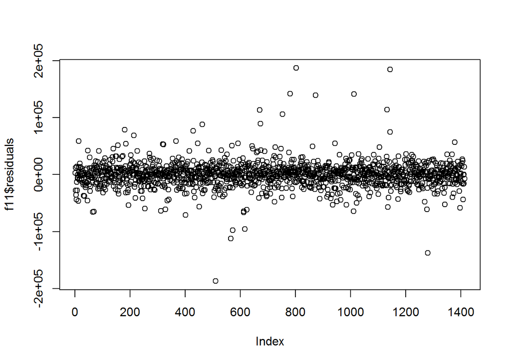

```r
plot(f11$residuals)
```

#### Analysis

```r
test <- read.csv(file="test.csv",head=TRUE,sep=",")
new_test<-test[ , !(names(test) %in% drops1)]
#new_test<-test[,'Id']
result_data <- predict(f11, new_test)
result_data<-cbind(test$Id,result_data)
colnames(result_data) <- c("Id","SalePrice")
#View(result_data)
```

```r
result_data<-data.frame(result_data)


for (i in 1:nrow(result_data)){
  if (is.na(result_data[i,2]))
   result_data[i,2]<-mean(result_data[,2], na.rm = TRUE)

}
```

```r
write.csv(result_data,"final.csv")
```

#### Kaggle Score

My Kaggle user name is **dhnanjay** and my score is **0.20060**

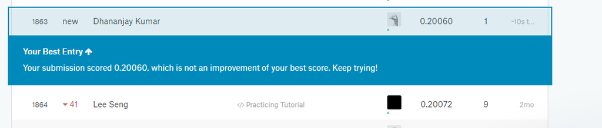